# ISyE 450, Spring 2019

# Optimizing Totes Mix Ratio, Totes Induction Rate and Staffing Level

#### Charlie Plunkett, Christopher Conrad, Hannah Nguyen, Shujing Wei, Ziyu Lin.

1. Introduction
2. Mathematical Model
3. Solution
4. Results and Discussion
5. Conclusion

Packages we use for this project: CSV, NamedArrays, PyPlot,JuMP, Gurobi

## 1. Introduction

Duluth distribution center launched a new tote packing system in 2018. The system consists of three main parts: Induction, Picking, and Packing. For simplication, we do not take Picking into account for this project. When this center receives orders, the induction point will release totes to the system and the totes will eventually flow to packing station. And packing stations will pack these totes. This distribution has two types of order: Conusmer and Retail. Thus, they have two types of packing stations which can only process the corresponding type of orders. There are 50 Consumer packing stations, and 48 Retail packing stations.

Duluth hopes that the orders can be finished as soon as possible. However, since the demand(number of orders coming in) is fluctuating and the staffing level of packing stations is prescheduled and thus lack of flexibility. It is very hard for them to finish all the totes within that day. Thus, they will take some cost for unmet demand every day, since the demand is not fulfilled quickly enough and this may lead to dissatisfaction of their clients. Also, they would take extra cost if the employees work overtime, since the overtime working is externally paid. Thus, overtime cost and unmet demand cost is like trade-off, since if more workers work overtime, less demand will be unfinished that day.

Since this is a new system, this company has not had the opportunity to perform analysis and derive insight from the system. Our first task is to analyze packing capacity under different staffing level for Consumer and Retail. Then, with the capacity analysis, we want to balance totes to different stations and make a plan for staffing level and set the production goal each day, so that the labor cost and cost of production delay could be minimized.

Shortly, our team aims to understand the product flow and find the capacity of each packing station. Moreover, our team intends to balance the work flow and develop standardized guidelines for optimal induction so that the daily throughput of the system could be maximized. This problem is a convex continuous nonlinear planning problem, since the capacity involves nonlinear relationship which we will discuss later. The data we use is directly from our client and is all real data.

[figure not shown]

## 2. Mathematical model

### 2.a Regression model

To understand the relationship between working time and how many totes can be packed per day. We use least square method to get the best fit line.In our model, Y represents the Packing Capacity( number of the Totes can be packed per day) and X represents Working Time(hour).

Here is the equation for 1st degree ploynomial(straight line) $$ \begin{equation} Y_j = \beta_0 + \beta_1 X_j + \epsilon_j \end{equation} $$

Here is the equation for 2nd degree ploynomial(quadratic function) $$ \begin{equation} Y_j = \beta_0 + \beta_1 X_j + \beta_2 X_j^2 + \epsilon_j \end{equation} $$

Here is the equation for 3rd degree ploynomial(cubic fit) $$ \begin{equation} Y_j = \beta_0 + \beta_1 X_j + \beta_2 X_j^2 + \beta_3 X_j^3 + \epsilon_j \end{equation} $$

Here is the matrix form $$ \begin{equation} \begin{bmatrix} y_1 \\ y_2 \\ \vdots \\ y_i \end{bmatrix}= \begin{bmatrix} x_1^2 & x_1 & 1\\ \ x_2^2 & x_2 & 1\\ \vdots & \vdots & \vdots\\ x_i^2 & x_i & 1 \end{bmatrix} \times \begin{bmatrix} \beta_0 \\ \beta_1 \\ \beta_2 \end{bmatrix} \end{equation} $$

Here is the standard form. It's an unconstrained optimization problem

$$ \underset{x \in \mathbb{R^n}}{\text{minimize}} ||Ax-b||^2 $$

### 2.b Optimization model

This project is different from traditional planning problem with inventory, backorder. Since the totes can only be packed after the distribution gets the order, there is no inventory. Instead, the production is always less or equal to demand, there will some unmet demand, which will go to the following days. To solve this, we build a model by ourselves, which is like the graph below. The dt represents demand coming in day t, xt represents the production in day, and ut represents the cumulative unmet demand at the start of day t. Shortly, when the demand is not met, it will become the unmet demand of the next day.

[figure not shown]

Here is the optimization model in standard form for the 1st scenario $$ \begin{aligned} \underset{x \in \mathbb{R^n}}{\text{minimize}} \qquad& \sum_{i=1...29,j=1...2} x_{ij} \\ \text{subject to:} \qquad& x_{i1} \le n_c*T_m && i=1,\dots,29 \\ \qquad& x_{i2} \le n_r*T_m && i=1,\dots,29 \\ \qquad& h_{1j} == 0 && j=1,2 \\ \qquad& h_{30j} == 0 && j=1,2 \\ \qquad& h_{ij} + d_{ij} == y_{ij} + h_{(i+1)j} && i=1,\dots,29, j=1,2 \\ \qquad& y_{ij} \le \beta_{2j} * x_{ij}^2 + \beta_{1j}*x_{ij} +\epsilon_j && i=1,\dots,29, j=1,2 \\ \qquad& \sum_{i=1...29,j=1...2}h_{ij} \le M_u \\ & \ x_{ij} \geq 0, y_{ij} \geq 0, h_{ij} \geq 0, d_{ij} \geq 0\\ \end{aligned} $$

$$ x_{ij}:\text{Number of totes packed in day i, which is type j }\\ h_{ij}:\text{Unmet demand (Sum of totes unpacked in day i, which is type j) }\\ n_c:\text{Number of consumer working stations}\\ n_r:\text{Number of retail working stations}\\ T_m:\text{Operating time per day(hour)}\\ M_u:\text{Maximum daily unment demand for either type(tote)}\\ \beta_{dj}:\text{Coefficient of corresponding d-degree element in regression model we just got for Type j}\\ $$

Here is the optimization model in standard form for the 2nd scenario

$$ \begin{aligned} \underset{o \in \mathbb{R^n}}{\text{minimize}} \qquad& \sum_{i=1...29,j=1...2} C_o * o_{ij} + \sum_{i=1...30,j=1...2} C_u * h_{ij} \\ \text{subject to:} \qquad& o_{ij} \le M_O*l_{ij} && i=1,\dots,29,j=1...2 \\ \qquad& h_{1j} == 0 && j=1,2 \\ \qquad& h_{30j} == 0 && j=1,2 \\ \qquad& h_{ij} + d_{ij} == y_{ij} + h_{(i+1)j} && i=1,\dots,29, j=1,2 \\ \qquad& y_{ij} \le \beta_{2j} * x_{ij}^2 + \beta_{1j}*x_{ij} +\epsilon_j && i=1,\dots,29, j=1,2 \\ \qquad& \sum_{i=1...29,j=1...2}h_{ij} \le M_u \\ & \ o_{ij} \geq 0, y_{ij} \geq 0, h_{ij} \geq 0, l_{ij} \geq 0, d_{ij} \geq 0\\ \end{aligned} $$

$$ C_o:\text{Overtime cost(dollars/ hour)}\\ C_u:\text{Ummet demand cost(dollars/ tote.day)}\\ o_{ij}:\text{Sum of overtime working time(hour) }\\ h_{ij}:\text{Unmet demand (Sum of totes unpacked in day i, which is type j) }\\ M_u:\text{Maximum daily unment demand for either type(tote)}\\ t_r:\text{Regular working time duration(hour)}\\ M_o:\text{Maximum overtime duration(hours/ person)}\\ $$

## 3. Solution

The table below contains the real data of December: the total working time and number of totes finished on each day.

```julia
# Load the raw data
using CSV
raw_data = CSV.read("DecemberData.csv")#, datarow =2)
```

|  | Column1 String⍰ | Consumer Working Time(hrs) Float64⍰ | Consumer Totes finished Int64⍰ | Reatil Working Time(hrs) Float64⍰ | Retail Totes finished Int64⍰ |
| --- | --- | --- | --- | --- | --- |
| 1 | 12/1/2018 | 469.0 | 2262 | 149.7 | 548 |
| 2 | 12/2/2018 | 581.7 | 2971 | 50.8 | 244 |
| 3 | 12/3/2018 | 630.4 | 3072 | 323.3 | 1770 |
| 4 | 12/4/2018 | 521.9 | 2865 | 446.3 | 2381 |
| 5 | 12/5/2018 | 467.9 | 2428 | 415.5 | 2036 |
| 6 | 12/6/2018 | 515.8 | 3039 | 277.7 | 1186 |
| 7 | 12/7/2018 | 496.2 | 2739 | 309.6 | 1197 |
| 8 | 12/8/2018 | 377.8 | 2332 | 216.0 | 1048 |
| 9 | 12/9/2018 | 387.9 | 2164 | 255.5 | 1129 |
| 10 | 12/10/2018 | 499.3 | 2805 | 432.5 | 1764 |
| 11 | 12/11/2018 | 534.6 | 3101 | 371.6 | 1440 |
| 12 | 12/12/2018 | 616.8 | 3224 | 338.4 | 1330 |
| 13 | 12/13/2018 | 602.2 | 3442 | 200.6 | 1171 |
| 14 | 12/14/2018 | 619.6 | 3001 | 261.8 | 1294 |
| 15 | 12/15/2018 | 516.3 | 2289 | 254.1 | 1227 |
| 16 | 12/16/2018 | 449.7 | 2265 | 198.7 | 1037 |
| 17 | 12/17/2018 | 711.3 | 3284 | 303.1 | 1177 |
| 18 | 12/18/2018 | 789.2 | 3442 | 247.4 | 1092 |
| 19 | 12/19/2018 | 473.0 | 2492 | 494.6 | 1893 |
| 20 | 12/20/2018 | 213.1 | 988 | 539.6 | 2450 |
| 21 | 12/21/2018 | 230.2 | 965 | 502.0 | 2529 |
| 22 | 12/22/2018 | 90.9 | 468 | 395.1 | 2744 |
| 23 | 12/23/2018 | 103.3 | 611 | 305.9 | 1533 |
| 24 | 12/26/2018 | 254.3 | 1346 | 744.2 | 2875 |
| 25 | 12/27/2018 | 198.4 | 1232 | 480.6 | 1733 |
| 26 | 12/28/2018 | 242.3 | 1407 | 274.6 | 831 |
| 27 | 12/29/2018 | 183.1 | 997 | 445.4 | 2376 |
| 28 | 12/30/2018 | 212.4 | 1400 | 297.9 | 1314 |
| 29 | 12/31/2018 | 148.9 | 768 | 371.3 | 1523 |

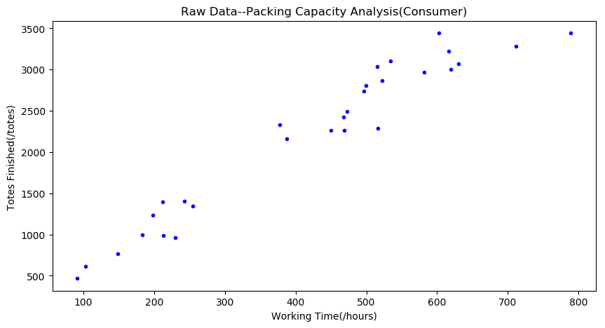

```julia
x = raw_data[:,2];# Consumer working time
y = raw_data[:,3];# number of Consumer totes finishd

using NamedArrays, PyPlot
function plotpoints()
    figure(figsize=(10,5))
    plot(x,y,"b.")
    xlabel("Working Time(/hours)")
    ylabel("Totes Finished(/totes) ")
    #xticks(0:10)
    title(string("Raw Data--Packing Capacity Analysis","(","Consumer",")"))
end
plotpoints();
```

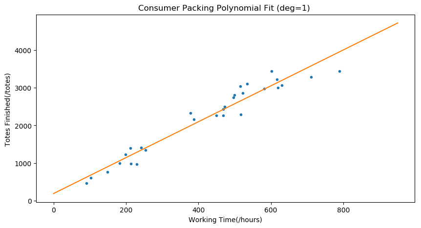

```
Equation is Y=4.764632136718084*X+192.0095669166978
```

```julia
# ORDINARY LEAST SQUARES
d =1                     #degree
n = length(x)            #length
A = zeros(n, d + 1)      #empty matrix
for j = 1:(d + 1)
    A[:, j] = x.^(j - 1)
end
what = A \ y             #Coefficients, using the built-in function of Jump
N = 1000
xfine = range(0, stop=950, length=N) |> collect
#xfine = range(x[1], stop=x[end], length=N) |> collect
Afine = zeros(N, d + 1)
for j = 1:(d + 1)
    Afine[:, j] = xfine.^(j - 1)
end
yhat = Afine * what

figure(figsize=(10,5))
plot(x, y, ".")
plot(xfine, yhat, "-")
title(string("Consumer Packing Polynomial Fit (deg=", d, ") "))
    xlabel("Working Time(/hours)")
    ylabel("Totes Finished(/totes) ")
println("Equation is Y=",what[2],"*X+",what[1]);
```

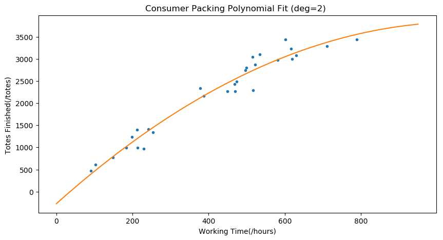

```
Equation is Y=-0.0036021424737674858*X^2+7.689633900328302*X+-272.4257782896836
```

```julia
# ORDINARY LEAST SQUARES
d =2
n = length(x)
A = zeros(n, d + 1)
for j = 1:(d + 1)
    A[:, j] = x.^(j - 1)
end
what = A \ y
N = 1000
xfine = range(0, stop=950, length=N) |> collect
Afine = zeros(N, d + 1)
for j = 1:(d + 1)
    Afine[:, j] = xfine.^(j - 1)
end
yhat = Afine * what

figure(figsize=(10,5))
plot(x, y, ".")
plot(xfine, yhat, "-")
title(string("Consumer Packing Polynomial Fit (deg=", d, ") "))
    xlabel("Working Time(/hours)")
    ylabel("Totes Finished(/totes) ")
println("Equation is Y=",what[3],"*X^2+",what[2],"*X+",what[1]);
```

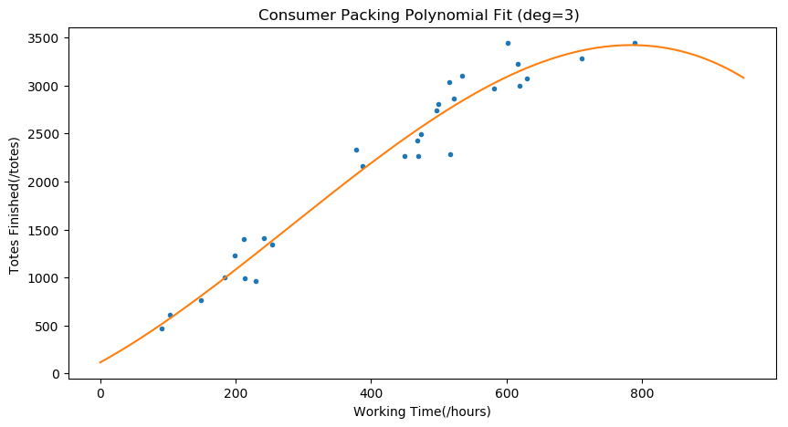

```
Equation is Y=-7.378089900581601e-6*X^3+0.0061962735593707255*X^2+3.8941703306179667*X+114.9159779445808
```

```julia
# ORDINARY LEAST SQUARES
d =3
n = length(x)
A = zeros(n, d + 1)
for j = 1:(d + 1)
    A[:, j] = x.^(j - 1)
end
what = A \ y #
N = 1000
xfine = range(0, stop=950, length=N) |> collect
#xfine = range(x[1], stop=x[end], length=N) |> collect
Afine = zeros(N, d + 1)
for j = 1:(d + 1)
    Afine[:, j] = xfine.^(j - 1)
end
yhat = Afine * what

figure(figsize=(10,5))
plot(x, y, ".")
plot(xfine, yhat, "-")
title(string("Consumer Packing Polynomial Fit (deg=", d, ") "))
    xlabel("Working Time(/hours)")
    ylabel("Totes Finished(/totes) ")
println("Equation is Y=",what[4],"*X^3+",what[3],"*X^2+",what[2],"*X+",what[1]);
```

### Comparsion of regression models in different degrees

Using Ordinary Least Square model, we tried to make regression in different degrees(d=1,2,3) to fit the raw data.

When d=1, the equation we got is "Y=4.764*X+192.009", which is a linear relation. However, this is not a good fit for the raw data, since when X=0(no working time), Y will be 192(192 totes packed). This is impossible in practice. Besides, the two nodes with largest X values(two nodes in the right) are both below the line. This means the equation dosen't fit the large X values well. Thus, degree=1 is not a good choice to fit our data.

When d=2, the equation we got is "Y=-0.0036*X^2+7.689*X+-272.426", this curve fits most of raw data nodes better. When X≈40, Y can go above 1. This means at least 40 working hours is required to have some totes packed. This is very consistent with the realistic condition, since the staffing level could never drop below 5 or 6 employees(providing about 40 working hours) on a day. The decreasing slope as X increases also make sense, since the productivity of individual employee may somehow decrease due to the limited equipments and space.

When d=3, the equation we got is "Y=-7.3781e-6*X^3+0.0062*X^2+3.894*X+114.916", this curve also fits most of raw data nodes better. However, there is an obvious peak at X≈800, and Y goes down sharply after X exceeds the peak. This pattern represents that the capacity of packing staitions will even decrease if the working time goes beyond 800 hours/day. In practice, this is nearly impossible, beacuse the properties of packing determines that more totes can always be finished if more working time is added. Also, the current layout is spacious, Duluth would not get into serious "overcrowded" problem and thus a drop in capacity is not very likely. So,degree=3 is not a good fit.

Although larger degree will always lead to better result in Ordinary Least Square, it may overfit the data and thus the eqaution may derivate a lot from the practical condition. For this problem, we selected Ordinary Least Square moodel in Degree=2 as our regression model for Packing Capacity Analysis for Consumer and also for Retail(Capacity Analysis below).

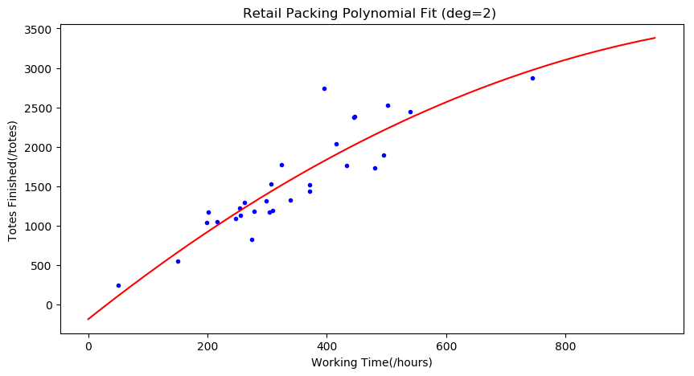

```
Equation is Y=-0.0023770825917807854*X^2+6.009993846385214*X+-184.3004079082067
```

```julia
x = raw_data[:,4];# Reatil working time
y = raw_data[:,5];# number of Retail totes finishd
# ORDINARY LEAST SQUARES
d =2
n = length(x)
A = zeros(n, d + 1)
for j = 1:(d + 1)
    A[:, j] = x.^(j - 1)
end
what = A \ y #
N = 1000
xfine = range(0, stop=950, length=N) |> collect
#xfine = range(x[1], stop=x[end], length=N) |> collect
Afine = zeros(N, d + 1)
for j = 1:(d + 1)
    Afine[:, j] = xfine.^(j - 1)
end
yhat = Afine * what

figure(figsize=(10,5))
plot(x, y, "b.")
plot(xfine, yhat, "r-")
title(string("Retail Packing Polynomial Fit (deg=", d, ") "))
    xlabel("Working Time(/hours)")
    ylabel("Totes Finished(/totes) ")
println("Equation is Y=",what[3],"*X^2+",what[2],"*X+",what[1]);
```

### Scenario1: The company can accurately predict the demand

```julia
using CSV
d = CSV.read("Demand.csv")
```

|  | Consumer Int64⍰ | Retail Int64⍰ |
| --- | --- | --- |
| 1 | 2308 | 611 |
| 2 | 3000 | 270 |
| 3 | 3143 | 1903 |
| 4 | 2384 | 2210 |
| 5 | 2241 | 1792 |
| 6 | 3179 | 1138 |
| 7 | 2458 | 994 |
| 8 | 2394 | 1155 |
| 9 | 2274 | 1097 |
| 10 | 2684 | 1356 |
| 11 | 3373 | 1323 |
| 12 | 2807 | 747 |
| 13 | 3512 | 391 |
| 14 | 2736 | 1263 |
| 15 | 2307 | 1422 |
| 16 | 1973 | 951 |
| 17 | 3597 | 785 |
| 18 | 2960 | 1511 |
| 19 | 1769 | 2328 |
| 20 | 1007 | 2002 |
| 21 | 834 | 1917 |
| 22 | 454 | 1381 |
| 23 | 559 | 1747 |
| 24 | 1333 | 2112 |
| 25 | 1273 | 1242 |
| 26 | 1293 | 1090 |
| 27 | 1003 | 1447 |
| 28 | 1413 | 834 |
| 29 | 824 | 1287 |

```julia
# Assumption 1: The company could predict the demand and schedule the staffing level, no worker working overtime
using JuMP,  Gurobi

m = Model(solver=GurobiSolver(OutputFlag=0,NumericFocus=3,BarHomogeneous=1))

@variable(m, x[1:29,1:2] >= 0) #working hours everyday for two departments: Consumer & Retail
@variable(m, y[1:29,1:2] >= 0) #number of totes finished
@variable(m, h[1:30,1:2] >= 0) #"cumulative unmet demand" at the start of each day

#maximum working hours for Consumer and Retail each day
@constraint(m, maxhours_Con[i in 1:29], x[i,1] <= 50*18)  # the number of consumer working stations is 50, working hours is 18 hours
@constraint(m, maxhours_Ret[i in 1:29], x[i,2] <= 48*18)  # the number of consumer working stations is 48, working hours is 18 hours

#zero unmet demand on the first day and the last day
@constraint(m, start[i in 1:2], h[1,i] == 0)
@constraint(m, ending[i in 1:2], h[30,i] == 0)

# starting unmet demand of this day+ new demand of this day=totes finished this day+ starting unmet demand of next day
@constraint(m, flowbal[i in 1:29,j in 1:2], h[i,j] + d[i,j] == y[i,j] + h[i+1,j])

# the finished totes<= the capacity function we got in the previous part
@constraint(m, capa_consumer[i in 1:29], y[i,1] <= (-0.0036*x[i,1]^2 + 7.69*x[i,1] - 272.44))
@constraint(m, capa_retail[i in 1:29],   y[i,2] <= (-0.0023*x[i,2]^2 + 6.01*x[i,2] - 184.24))

#  unmet demand could not exceed 300
@constraint(m, unmet_demand[i in 1:29], sum(h[i,j] for j in 1:2) <= 300)
@objective(m, Min, sum(x[i,j] for i in 1:29 for j in 1:2)) #+ 0.01*sum(h[i,j] for i in 1:30 for j in 1:2))

status = solve(m);
xopt = getvalue(x);
yopt = getvalue(y);
hopt = getvalue(h);
```

```
Academic license - for non-commercial use only
```

### Scenario2: The company cannot accurately predict the demand

In the second scenario, we assume that the distribution center cannot accurately predict the demand. The staffing level is prescheduled in advance, so the number of employees for Consumer and Retail is determined(the number in the table above).However, employees could work overtime, the extra pay of overtime is 8 dollars/hour. Using the model below, we try to minimize the loss of distribution center(cost of overtime payment and loss of unmet demand), by arranging how many totes of each type be inducted every day and how long emloyees of both types work overtime every day.

```julia
using CSV
l = CSV.read("StaffingLevel.csv")
```

|  | Consumer Int64⍰ | Retail Int64⍰ |
| --- | --- | --- |
| 1 | 95 | 33 |
| 2 | 107 | 12 |
| 3 | 100 | 59 |
| 4 | 90 | 74 |
| 5 | 103 | 75 |
| 6 | 107 | 47 |
| 7 | 83 | 45 |
| 8 | 82 | 43 |
| 9 | 70 | 42 |
| 10 | 112 | 69 |
| 11 | 100 | 67 |
| 12 | 105 | 59 |
| 13 | 113 | 46 |
| 14 | 104 | 50 |
| 15 | 90 | 48 |
| 16 | 79 | 39 |
| 17 | 116 | 64 |
| 18 | 100 | 57 |
| 19 | 84 | 80 |
| 20 | 52 | 85 |
| 21 | 40 | 81 |
| 22 | 28 | 64 |
| 23 | 24 | 54 |
| 24 | 49 | 78 |
| 25 | 54 | 71 |
| 26 | 49 | 74 |
| 27 | 50 | 69 |
| 28 | 43 | 50 |
| 29 | 32 | 68 |

```julia
#calculate the working hour per day for scenario 2
# average working hours for each employee is 5.5 hours/day
working_hour2 =zeros(29,2)
for i in 1:29
    for j in 1:2
        working_hour2[i,j] = 5.5*l[i,j]
    end
end
```

```julia
# Assumption 2: The staffing level is prescheduled in advance, so the number of employees for Consumer and Retail is fixed.
# However, employees could work overtime, the extra pay of overtime is 8 dollars/hour
using JuMP,  Gurobi
m = Model(solver=GurobiSolver(OutputFlag=0,NumericFocus=3,BarHomogeneous=1))


@variable(m, o[1:29,1:2] >= 0) #overtime working hours everyday for two departments: Consumer & Retail
@variable(m, y[1:29,1:2] >= 0) #number of totes finished
@variable(m, h[1:30,1:2] >= 0) #"cumulative unmet demand" at the start of each day

#maximum overtime working hours for Consumer and Retail each day
@constraint(m, overtime_Con[i in 1:29], o[i,1] <= 2*l[i,1])  # each employee's overtime  is at most 2 hours
@constraint(m, overtime_Ret[i in 1:29], o[i,2] <= 2*l[i,2])  # each employee's overtime  is at most 2 hours


#zero unmet demand on the first day and the last day
@constraint(m, start[i in 1:2], h[1,i] == 0)
@constraint(m, ending[i in 1:2], h[30,i] == 0)

# starting unmet demand of this day+ new demand of this day=totes finished this day+ starting unmet demand of next day
@constraint(m, flowbal[i in 1:29,j in 1:2], h[i,j] + d[i,j] == y[i,j] + h[i+1,j])

# the finished totes<= the capacity function we got in the previous part
@constraint(m, capa_consumer[i in 1:29], y[i,1] <= (-0.0036*(5.5*l[i,1]+o[i,1])^2 + 7.69*(5.5*l[i,1]+o[i,1]) - 272.44))
@constraint(m, capa_retail[i in 1:29],   y[i,2] <= (-0.0023*(5.5*l[i,2]+o[i,2])^2 + 6.01*(5.5*l[i,2]+o[i,2]) - 184.24))

#  unmet demand could not exceed 300
#  $8/hour is the overtime labor cost. $0.1/tote.day is the delay cost(unmet demand cost)
@constraint(m, unmet_demand[i in 1:29], sum(h[i,j] for j in 1:2) <= 300)
@objective(m, Min, 8*sum(o[i,j] for i in 1:29 for j in 1:2)+ 0.1*sum(h[i,j] for i in 1:30 for j in 1:2))

status = solve(m);

yopt2 = getvalue(y);
oopt2 = (getvalue(o))
for i=1:29
    for j=1:2
oopt2[i,j]=round(Int,oopt2[i,j])
                                end
                            end
```

```
Academic license - for non-commercial use only
```

```julia
#round up working hour to two digits
xopttest = xopt

for i in 1:29
    for j in 1:2
        xopttest[i,j] = round(xopt[i,j], digits = 2)
    end
end

#round up working hour to two digits
yopt2test = yopt2

for i in 1:29
    for j in 1:2
        yopt2test[i,j] = round(yopt2[i,j], digits = 2)
    end
end
```

## 4. Results and Discussion

Each scenario gives us two set of totes finished on each day of the December month. In order to compare each scenario, we will display the result from each scenario and analyze the similarity or differences between them by visualizing with graphs.

## 4.A. Scenario 1

We will display the optimal working hours as well as the number of totes finished on each day below. In this scenario, we minimize the number of working hours assuming we have the flexiblity for our labor hours to flunctuate depending on the demand.

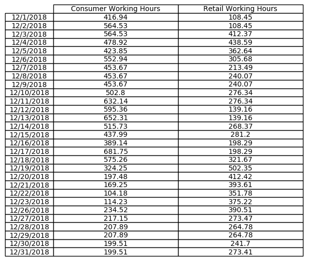

```
(0.0, 1.0, 0.0, 1.0)
```

```julia
#display result for assumption 1
using PyPlot
columns = ["Consumer Working Hours","Retail Working Hours"]

#println("test")
table(cellText=xopttest,
            rowLabels=raw_data[:,1],
            label= "test",
            #rowColours=colors,
            colLabels=columns,
            loc="center",
            colLoc="center",
            rowLoc="center",
            cellLoc = "center")

axis("off")
```

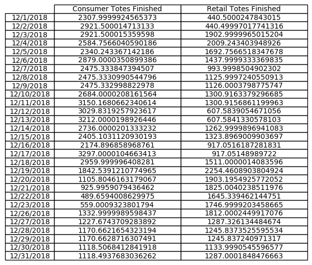

```
(-0.05500000000000001, 0.05500000000000001, -0.05500000000000001, 0.05500000000000001)
```

```julia
#display result for scenario 1
using PyPlot
columns = ["Consumer Totes Finished","Retail Totes Finished"]

#println("test")

table(cellText=yopt,
            rowLabels=raw_data[:,1],
            label= "test",
            #rowColours=colors,
            colLabels=columns,
            loc="center",
            colLoc="center",
            rowLoc="center",
            cellLoc = "center")

axis("off")
axis("tight")
```

## 4.B. Scenario 2

We will display the optimal the number of totes finished as well as OVERTIME working hours on each day below. In this scenario, we minimize the number of overtime working hours assuming we do not have the flexiblity for our labor hours to flunctuate depending on the demand. Hence, we have a fixed staffing level and can schedule overtime hours.

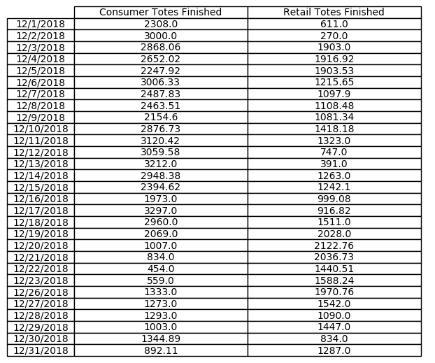

```
(0.0, 1.0, 0.0, 1.0)
```

```julia
##display result for scenario 2
using PyPlot
columns = ["Consumer Totes Finished","Retail Totes Finished"]

#println("test")

table(cellText=yopt2test,
            rowLabels=raw_data[:,1],
            label= "test",
            #rowColours=colors,
            colLabels=columns,
            loc="center",
            colLoc="center",
            rowLoc="center",
            cellLoc = "center")
axis("off")
```

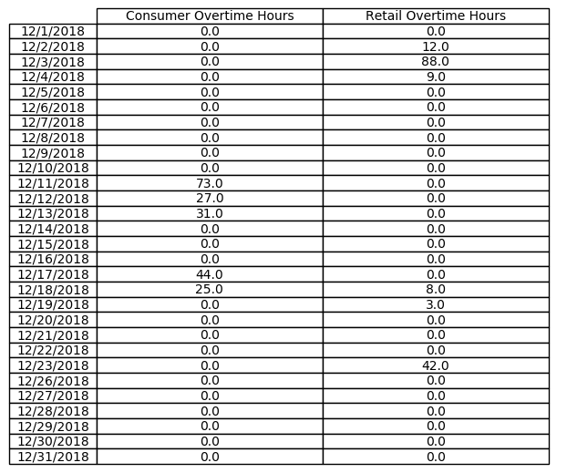

```
(0.0, 1.0, 0.0, 1.0)
```

```julia
#display result for scenario 2
using PyPlot
columns = ["Consumer Overtime Hours","Retail Overtime Hours"]

#println("test")

table(cellText=oopt2,
            rowLabels=raw_data[:,1],
            label= "test",
            #rowColours=colors,
            colLabels=columns,
            loc="center",
            colLoc="center",
            rowLoc="center",
            cellLoc = "center")

axis("off")
```

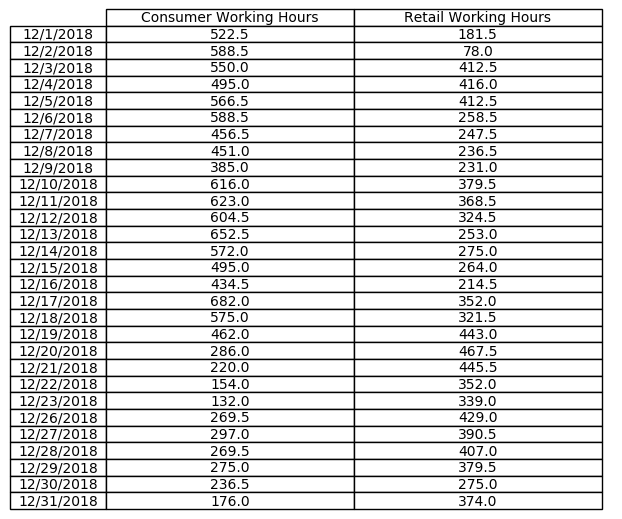

```
(0.0, 1.0, 0.0, 1.0)
```

```julia
#total working hours for scenario 2 including overtime hours
xopt2 = working_hour2 + oopt2
using PyPlot
columns = ["Consumer Working Hours","Retail Working Hours"]

#println("test")

table(cellText=xopt2,
            rowLabels=raw_data[:,1],
            label= "test",
            #rowColours=colors,
            colLabels=columns,
            loc="center",
            colLoc="center",
            rowLoc="center",
            cellLoc = "center")

axis("off")
```

## 4.C. Comparison

For each graph below, we will display the same attribute from different scenario.

1. The number of totes finished for the Consumer side
2. The number of totes finished for the Retail side
3. The working hours for the Consumer side
4. The working hours for the Retail side

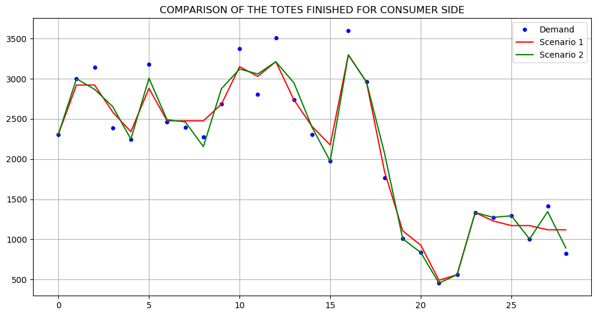

```julia
using PyPlot
figure(figsize=(12,6))
plot(d[:,1],"b.", markersize=8)
plot(yopt[:,1],"r-")
plot(yopt2[:,1],"g-")
legend(["Demand", "Scenario 1", "Scenario 2"])
title("COMPARISON OF THE TOTES FINISHED FOR CONSUMER SIDE")
grid()
```

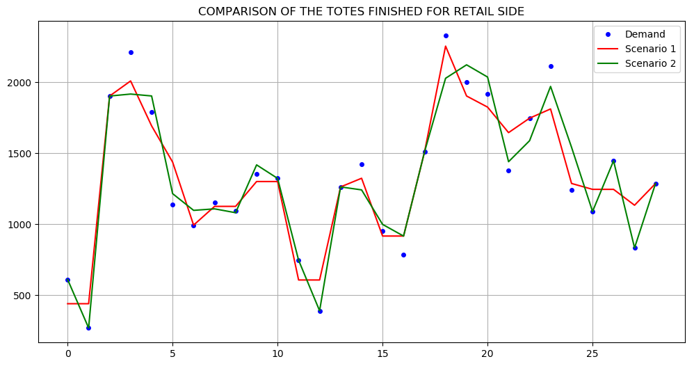

```julia
using PyPlot
figure(figsize=(12,6))
plot(d[:,2],"b.", markersize=8)
plot(yopt[:,2],"r-")
plot(yopt2[:,2],"g-")
legend(["Demand", "Scenario 1", "Scenario 2"])
title("COMPARISON OF THE TOTES FINISHED FOR RETAIL SIDE")
grid()
```

### 4.C.2. Number of Working Hours

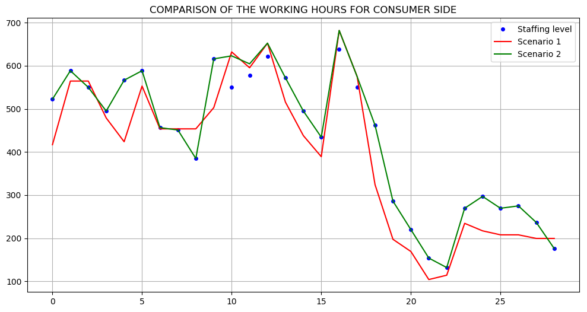

```julia
using PyPlot
figure(figsize=(12,6))
plot(working_hour2[:,1],"b.", markersize=8)
plot(xopt[:,1],"r-")
plot(xopt2[:,1],"g-")
legend(["Staffing level", "Scenario 1", "Scenario 2"])
title("COMPARISON OF THE WORKING HOURS FOR CONSUMER SIDE")
grid()
```

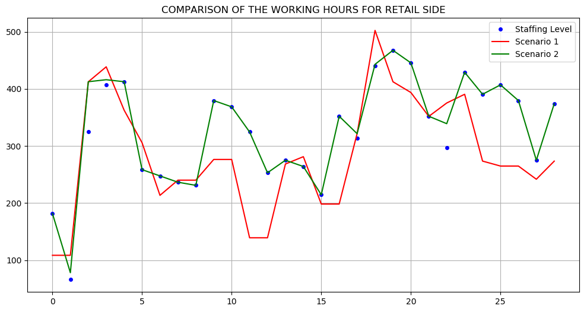

```julia
using PyPlot
figure(figsize=(12,6))
plot(working_hour2[:,2],"b.", markersize=8)
plot(xopt[:,2],"r-")
plot(xopt2[:,2],"g-")
legend(["Staffing Level", "Scenario 1", "Scenario 2"])
title("COMPARISON OF THE WORKING HOURS FOR RETAIL SIDE")
grid()
```

```julia
sumWH1 = round(sum(xopt), digits = 3)
sumWH2 = round(sum(xopt2), digits = 3)

println("On the other hand, the sum of working hours for scenario 1 is: ",sumWH1, " hours.")
println("The sum of working hours for scenario 2 is: ",sumWH2, " hours.")
println("Scenario 1 saves: ", round((sumWH2 - sumWH1), digits = 3) ," labor hours or ",
        round((sumWH2-sumWH1)*100/sumWH1, digits = 3), "%.")
```

```
On the other hand, the sum of working hours for scenario 1 is: 19793.72 hours.
The sum of working hours for scenario 2 is: 22164.0 hours.
Scenario 1 saves: 2370.28 labor hours or 11.975%.
```

We expect this because for scenario 1, we try to minimize the number of working hours. While optimizing for scenario 2, we try to minimize the overtime given the fixed number of staffing level. There is a trade off between following the demand closely and decreasing the working hours/labor needed. Thus,if the company could perfectly predict the future demand, a huge portion of labor cost could be saved.

## 5. Conclusion

With scenario-1 model, the distribution center can pre-schedule the staffing level based on the prediction for the future demand. This can make sure majority of the orders can be finished within a short period of time. However, the predition of demand cannot be very accurate, the differnece between predicted demand and real demand may cause delay in production.

In practice, no model can be useful until it goes through a long-term test. To improve this model, we need more data and test runs. In conclusion, this is not a finalized version. We build a mode which is with complexibility so that the distribution center could change some parameters and find their best solution.

## Works cited

Amemiya, Takeshi (1985). Advanced econometrics. Harvard University Press. ISBN 0-674-00560-0.

Wenyu Sun; Ya-Xiang Yua (2010). Optimization Theory and Methods: Nonlinear Programming, Springer, ISBN 978-1441937650.